# Movement Ecology Workshop-ATBC 2023

Data Overview and preparation

Supratim, Nilanjan

30 June, 2023

There are currently hundreds of libraries to analyse movement data. For a detailed review please see Joo et al. 2019. We will use some important core packages necessary for analysis. This is by no means an exhaustive list. Please install the updated version of these packages or update if you have an earlier version.

### Loading the libraries

```r
library(move2) # download movement data
library(sf) # handle spatial data
library(ggplot2) # higher level plotting
library(tmap) # spatial data visualization
library(mapview) #interactive mapping
library(amt) # Movement data analysis
library(adehabitatLT) #movement data analysis
library(dplyr) # basic operations on the data
```

# Data Processing

Download data from `Movebank` *https://www.movebank.org/cms/movebank-main* by study id and Check the columns of the data

```r
dat <- mt_read("Hornbill telemetry in northeast India.csv")
head(dat)
```

```
## A <move2> object containing 1 track consisting of:
## Simple feature collection with 6 features and 7 fields
## Geometry type: POINT
## Dimension:     XY
## Bounding box:  xmin: 92.95335 ymin: 26.94604 xmax: 92.9538 ymax: 26.94736
## Geodetic CRS:  WGS 84
## # A tibble: 6 × 8
##   `event-id` visible timestamp           `import-marked-outlier` `sensor-type`
## *    <int64> <lgl>   <dttm>              <lgl>                   <fct>
## 1 9924979388 TRUE    2016-03-05 00:27:00 NA                      gps
## 2 9924979389 TRUE    2016-03-05 00:30:00 NA                      gps
## 3 9924979390 TRUE    2016-03-05 00:45:00 NA                      gps
## 4 9924979391 TRUE    2016-03-05 01:00:00 NA                      gps
## 5 9924979392 TRUE    2016-03-05 01:15:00 NA                      gps
## 6 9924979393 TRUE    2016-03-05 01:30:00 NA                      gps
## # ℹ 3 more variables: `tag-local-identifier` <fct>,
## #   `individual-local-identifier` <fct>, geometry <POINT [°]>
## Track features:
## # A tibble: 1 × 3
##   `individual-taxon-canonical-name` `study-name`          individual-local-ide…¹
##   <fct>                             <fct>                 <fct>
## 1 Buceros bicornis                  Hornbill telemetry i… 6_tkbhai
## # ℹ abbreviated name: ¹`individual-local-identifier`
```

```r
glimpse(dat)
```

```
## Rows: 19,275
## Columns: 8
## $ `event-id`                    <int64> 9924979388, 9924979389, 9924979390, 99…
## $ visible                       <lgl> TRUE, TRUE, TRUE, TRUE, TRUE, TRUE, TRUE…
## $ timestamp                     <dttm> 2016-03-05 00:27:00, 2016-03-05 00:30:0…
## $ `import-marked-outlier`       <lgl> NA, NA, NA, NA, NA, NA, NA, NA, NA, NA, …
## $ `sensor-type`                 <fct> gps, gps, gps, gps, gps, gps, gps, gps, …
## $ `tag-local-identifier`        <fct> GR5NBr, GR5NBr, GR5NBr, GR5NBr, GR5NBr, …
## $ `individual-local-identifier` <fct> 6_tkbhai, 6_tkbhai, 6_tkbhai, 6_tkbhai, …
## $ geometry                      <POINT [°]> POINT (92.9538 26.94707), POINT (9…
```

# Plotting the data

## Static map

We’ll use either *ggplot* or *tmap* package to plot the data We will also convert the spatial points into line-strings to plot the trajectory of the animal

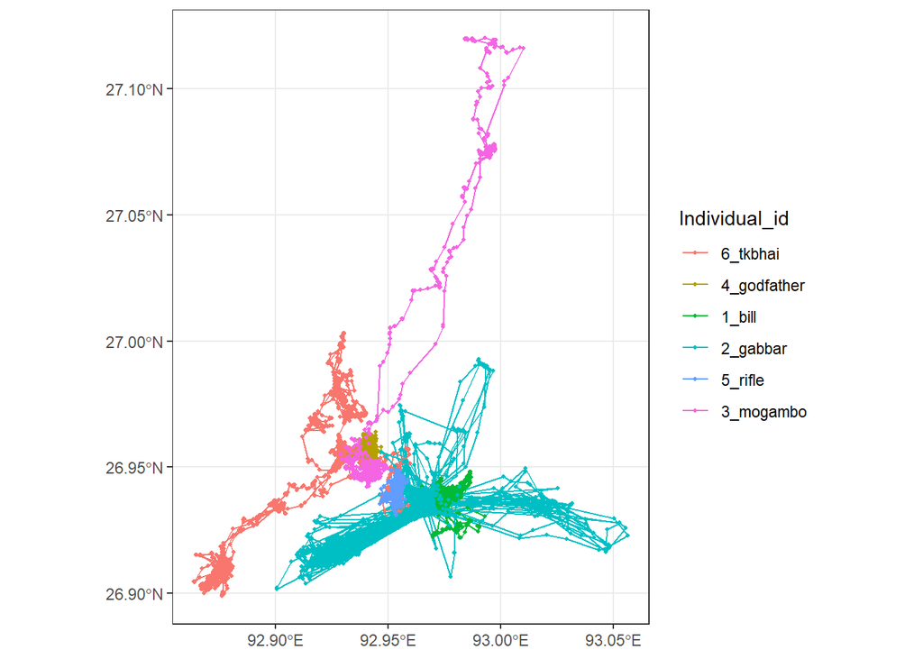

```r
trck <- dat %>%
  group_by(`individual-local-identifier`) %>%
  summarise(do_union = FALSE) %>%
  st_cast("LINESTRING")

ggplot()+
  geom_sf(data= trck , aes(col= `individual-local-identifier`))+
  geom_sf(data= dat , aes(col= `individual-local-identifier`), size=0.8)+
  theme_bw()+
  labs(col = "Individual_id")
```

## Interactive map

There are programs like *leaflet* or *mapview* to plot the data interactively

```r
mapview(dat$geometry, cex=0.5, alpha=0.5, map.types = "Esri.WorldImagery") +
  mapview(trck, map.types = "Esri.WorldImagery")
```

[interactive chart not shown]

# Creating *track* from the data

The coordinates were extracted from the dataset downloaded from `Movebank` *https://www.movebank.org/cms/movebank-main* and then added that to the dataset as the downloaded dataset have a single column for the geometry. The **CRS** used here to convert the lat-long projection system into a lcc projection system as the calculations further (step-length) will be done in meters.

```r
dat_proj <-st_transform(dat, crs= "ESRI:102030")
coords <-st_coordinates(dat_proj)
data_df <-cbind(dat_proj, coords)


data_df_trck <-data_df |>
   make_track( .x = X, .y = Y, .t = timestamp,
              crs= st_crs("ESRI:102030"), Individual_id = individual.local.identifier)

head(data_df_trck) #Check the track object from the *amt* package
```

```
## # A tibble: 6 × 4
##          x_       y_ t_                  Individual_id
## *     <dbl>    <dbl> <dttm>              <fct>
## 1 -3825091. 4497282. 2015-03-02 04:53:00 1_bill
## 2 -3825075. 4497307. 2015-03-02 05:00:00 1_bill
## 3 -3825112. 4497172. 2015-03-02 05:16:00 1_bill
## 4 -3825117. 4497149. 2015-03-02 05:30:00 1_bill
## 5 -3825330. 4497206. 2015-03-02 05:45:00 1_bill
## 6 -3825383. 4497206. 2015-03-02 06:01:00 1_bill
```

# Basic trajectory statistics

In this step, we would calculate basic summary statistics for each of the tagged individuals The output table shows summary distribution of the fix intervals for each individuals, how many locations were collected

```r
track_sum <-data_df_trck %>%
  nest(data= -"Individual_id") %>%
  mutate(sr = map(data, summarize_sampling_rate)) %>%
  dplyr::select(Individual_id, sr) %>%
  unnest(cols=sr) %>%
  print(n=nrow(data_df_trck))
```

```
## # A tibble: 6 × 10
##   Individual_id   min    q1 median  mean    q3   max    sd     n unit
## * <fct>         <dbl> <dbl>  <dbl> <dbl> <dbl> <dbl> <dbl> <int> <chr>
## 1 1_bill            7    15     15  28.2    15  1184  88.7  3979 min
## 2 2_gabbar         13    15     15  24.6    15   961  68.4  4706 min
## 3 3_mogambo         1    15     15  29.5    15   946  94.9  2606 min
## 4 4_godfather       7    15     15  24.8    15   751  70.3  2961 min
## 5 5_rifle          13    15     15  24.5    15   600  68.8  1117 min
## 6 6_tkbhai          3    15     15  24.4    15   601  67.9  3900 min
```

Try to focus on the median fix interval as collars can malfunction sometimes for data uploads.  
First quartile, Median fix-interval and third quartile of the data is 15 minutes which shows the data collection was very regular. ## Creating trajectory

```r
track_length <- data_df_trck |>
  nest(data= -"Individual_id") |>
  mutate(data = map(data, ~ .x |>
                      steps()))|>
  unnest(cols = data)
```

# Plotting trajectory distribution

We will plot the individual-wise distributions of step-length (m) and turn angle (radians) to see how individuals move.  
## Step-length distribution

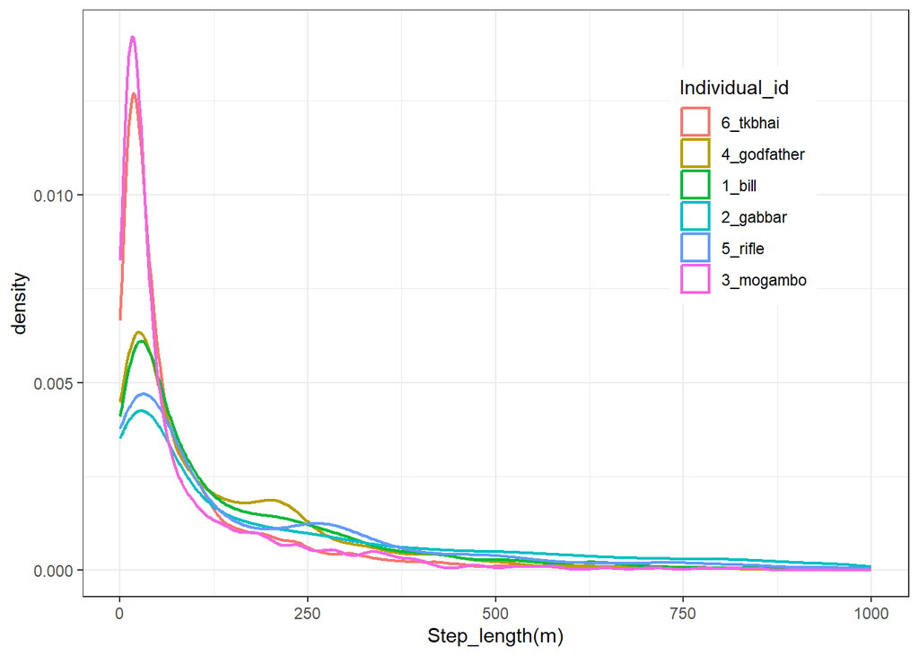

```r
ggplot(track_length)+
  geom_density(aes(x=sl_, col = Individual_id), linewidth=0.8) +
  xlim(0,1000)+
  labs(x= "Step_length(m)")+
  theme_bw() +
  theme(legend.position = c(0.8,0.7))
```

## Turn-angle distribution

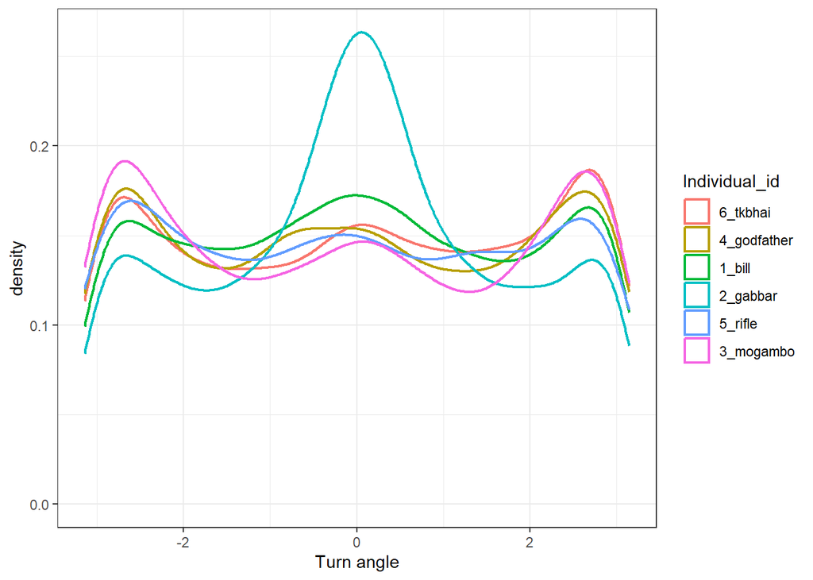

```r
ggplot(track_length)+
  geom_density(aes(x=ta_, col = Individual_id), linewidth=0.8) +
  labs(x= "Turn angle")+
  theme_bw()
```

# Home-range Analysis

```r
## MCP analysis
dat_hr_mcp <- data_df_trck |>
  nest(data = -"Individual_id") |>
  mutate(mcp_dat = map(data, ~ .x |>
                      hr_mcp(levels = c(0.5,0.95)))) |>
  mutate(mcp_area = map(.x = mcp_dat, .f = ~hr_area(.x)))|>
  unnest(cols = mcp_area)
colnames(dat_hr_mcp)[6] <- "MCP_area (sq.mtr)"

## KDE analysis
dat_hr_kde <- data_df_trck |>
  nest(data= -"Individual_id") |>
  mutate(kde_dat = map(data, ~ .x |>
                         hr_kde(levels = c(0.5,0.95)))) |>
  mutate(area = map(.x = kde_dat, .f = ~hr_area(.x)))|>
  unnest(cols = area)
colnames(dat_hr_kde)[6] <-"KDE_area (sq.mtr)"

## combining both the data
dat_hr <- cbind(dat_hr_mcp[,c(1,4,6)], dat_hr_kde[,6])
dat_hr
```

```
##    Individual_id level MCP_area (sq.mtr) KDE_area (sq.mtr)
## 1         1_bill  0.95         2268209.1         1632061.4
## 2         1_bill  0.50          297555.1          214209.0
## 3       2_gabbar  0.95        62675267.6        38255591.1
## 4       2_gabbar  0.50         4332655.6         4911711.4
## 5      3_mogambo  0.95        73002949.1       181684375.5
## 6      3_mogambo  0.50        31353151.8        30863779.0
## 7    4_godfather  0.95         1192254.8          977971.5
## 8    4_godfather  0.50          206269.8          164816.5
## 9        5_rifle  0.95         1741197.5         1553738.8
## 10       5_rifle  0.50          350205.8          259136.7
## 11      6_tkbhai  0.95        66227790.5        77856891.6
## 12      6_tkbhai  0.50        33930222.3        16360550.2
```

# Plotting the Home-range

## Calculate the convex hulls for each individual

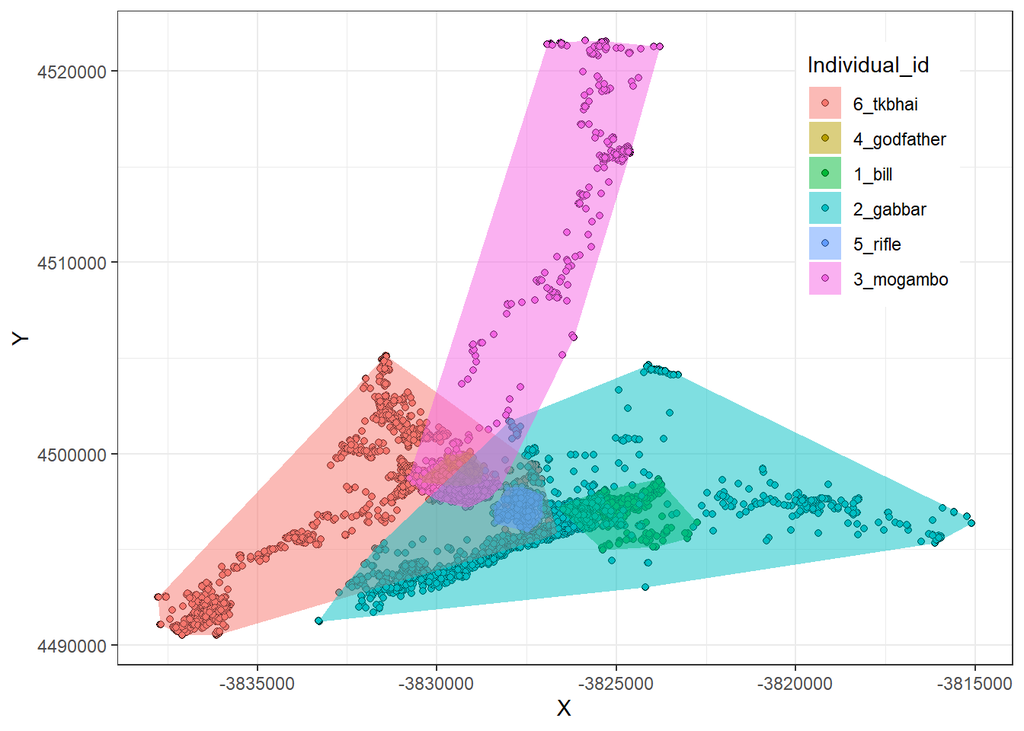

```r
hull_dat <- data_df %>%
  group_by(individual.local.identifier) %>%
  slice(chull(X, Y))

# Update the plot with a fill group, and overlay the new hulls
ggplot(data_df, aes(X, Y)) + geom_point(shape = 21)+
  aes(fill = individual.local.identifier) +
  geom_polygon(data = hull_dat, alpha = 0.5)+
  labs(fill = "Individual_id")+
  theme_bw() + theme(legend.position = c(0.85,0.75))
```